# Pearson Correlation and Gaussian Regression - Exercise Solutions

BICF@UTSouthwestern.edu

January 11, 2019

**1. Run the following code to generate a sample of size 50 from the Student t distribution with degree of freedom 30, and then:**

- **generate a histogram of sample x;**
- **calculate its summary statistics (min, Q1, median, mean, Q3, max);**
- **generate a Q-Q plot with 95% CI for sample x;**
- **run Shapiro-Wilk normality test on sample x.**

```r
set.seed(57)
x <- rt(n=50,df=30)
```

**Solution:**

```r
hist(x, breaks=15)  ## a  histogram of sample x
summary(x)    ##  summary statistics of x
```

```
##     Min.  1st Qu.   Median     Mean  3rd Qu.     Max.
## -2.14200 -0.91750  0.03698 -0.06852  0.60500  2.11500
```

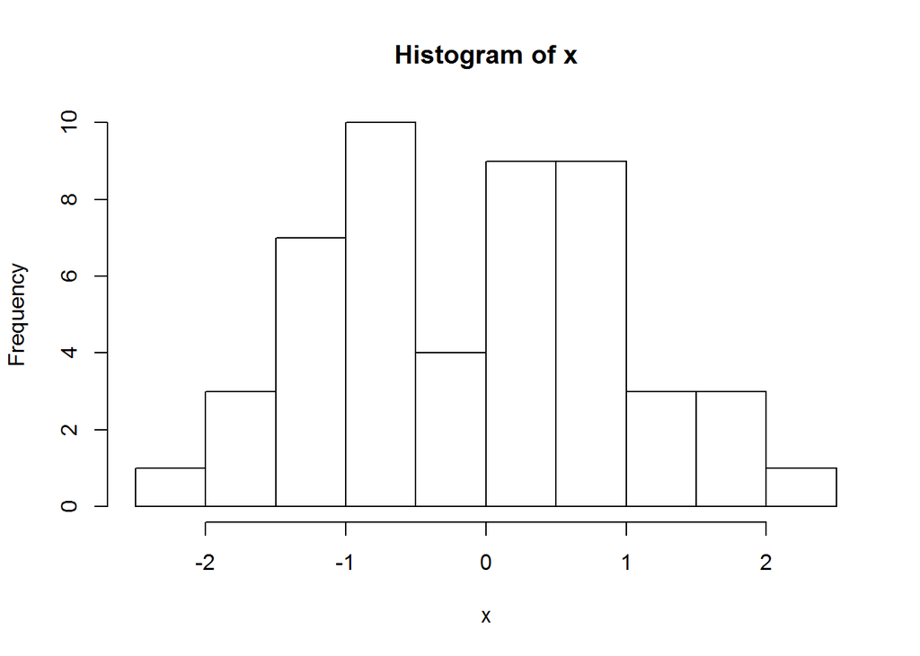

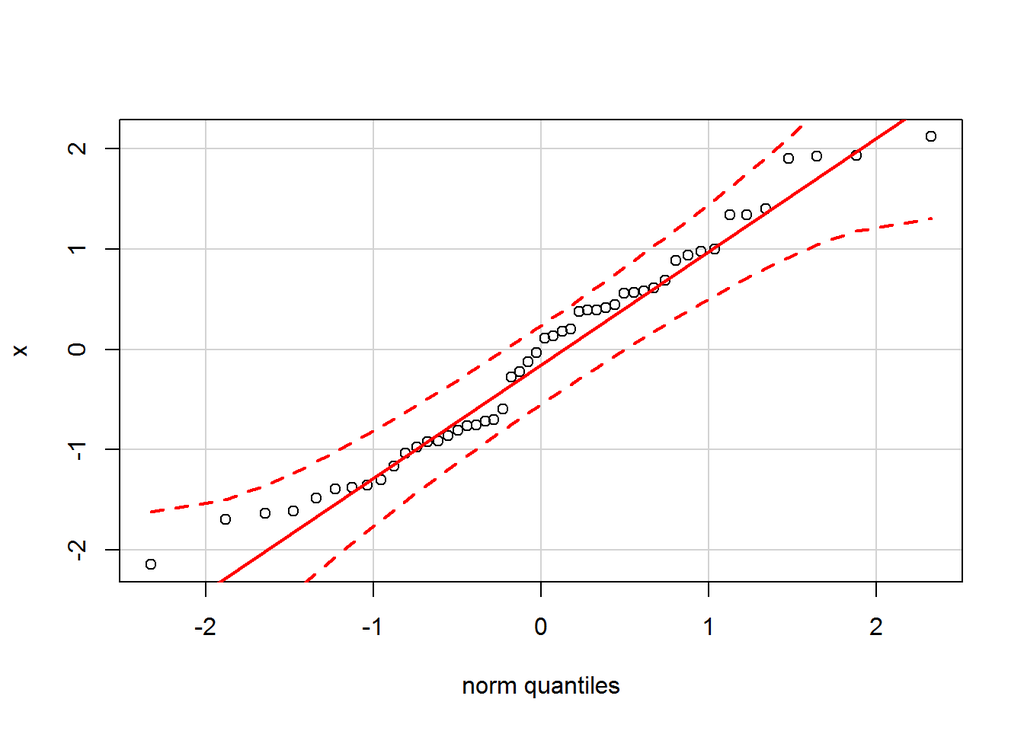

```r
car::qqPlot(x)  ## Q-Q plot with 95% CI for x
```

```r
shapiro.test(x)  ## Shapiro-Wilk normality test
```

```
##
##  Shapiro-Wilk normality test
##
## data:  x
## W = 0.96843, p-value = 0.1996
```

**2. Run the following simulation code first and then:**

- **calculate and test the Pearson correlation between x and y**
- **generate a scatter plot of x vs. y**

```r
set.seed(1234)
x <- rnorm(1000, 3, 0.5)
y <- 3-5*x+3*rnorm(1000)
```

**Solution:**

```r
cor.test(x,y)  ## Pearson correlation
```

```
##
##  Pearson's product-moment correlation
##
## data:  x and y
## t = -25.01, df = 998, p-value < 2.2e-16
## alternative hypothesis: true correlation is not equal to 0
## 95 percent confidence interval:
##  -0.6574083 -0.5810789
## sample estimates:
##        cor
## -0.6207122
```

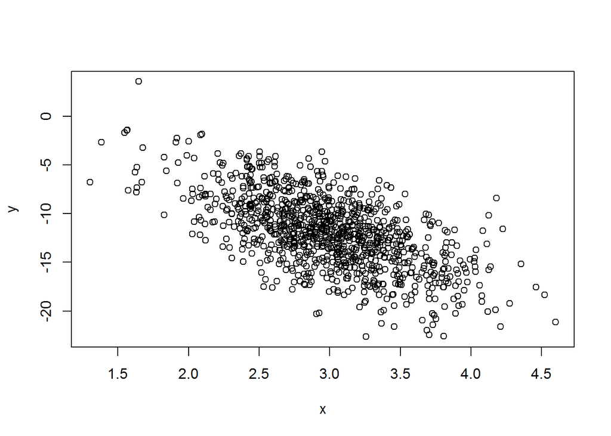

```r
plot(x,y)  ## scatter plot
```

**3. Run the following simulation code first and then choose an appropriate test to compare the mean of sample x1 and x2. And then check the sample sizes.**

```r
set.seed(57)
x1 <- rnorm(30, 2.2, 1)
x2 <- rnorm(30, 2.0, 1)
```

**Solution:**

```r
shapiro.test(x1)  ## Shapiro-Wilk normality test
```

```
##
##  Shapiro-Wilk normality test
##
## data:  x1
## W = 0.96923, p-value = 0.5183
```

```r
shapiro.test(x2)
```

```
##
##  Shapiro-Wilk normality test
##
## data:  x2
## W = 0.95732, p-value = 0.2642
```

```r
t.test(x1, x2)  ## two-sample t test
```

```
##
##  Welch Two Sample t-test
##
## data:  x1 and x2
## t = 0.39001, df = 54.354, p-value = 0.6981
## alternative hypothesis: true difference in means is not equal to 0
## 95 percent confidence interval:
##  -0.5071571  0.7521677
## sample estimates:
## mean of x mean of y
##  2.268637  2.146132
```

```r
length(x1)  ## check sample sizes
```

```
## [1] 30
```

```r
length(x2)
```

```
## [1] 30
```

**4. Run the following simulation first and then:**

- **test linear association between x and y**
- **generate the scatter plot of x vs. y**

```r
set.seed(1234)
r <- runif(1000, -pi,pi)
x <- 16*sin(r)^3
y <- 13*cos(r)-5*cos(2*r)-2*cos(3*r)-cos(4*r)+rnorm(1000)
```

**Solution:**

```r
cor.test(x,y)  ## test linear association using Pearson correlation
```

```
##
##  Pearson's product-moment correlation
##
## data:  x and y
## t = -0.45893, df = 998, p-value = 0.6464
## alternative hypothesis: true correlation is not equal to 0
## 95 percent confidence interval:
##  -0.07644984  0.04751026
## sample estimates:
##        cor
## -0.0145256
```

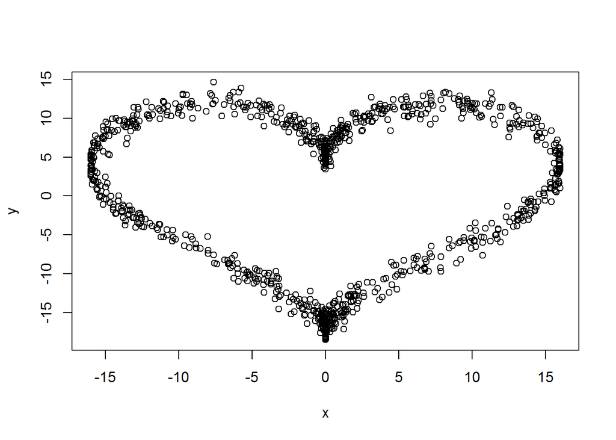

```r
plot(x,y)   ## scatter plot
```

**5. Run the following simulation code first and then:**

- **regress y on x**
- **generate the model diagnostic plots**
- **plot the histgram of x**
- **calculate mean of x**
- **plot the histgram of y**
- **calculate mean of y**
- **what is the relation between mean of x and mean of y?**
- **calculate and test the Pearson correlation between x and y**

```r
set.seed(1234)
x <- rnorm(1000, 5, 2)
y <- 3+5*x+rnorm(1000)
```

**Solution:**

```r
fit <- lm(y~x)
summary(fit)   ## regress y on x
```

```
##
## Call:
## lm(formula = y ~ x)
##
## Residuals:
##     Min      1Q  Median      3Q     Max
## -3.1661 -0.6439  0.0145  0.6537  3.0684
##
## Coefficients:
##             Estimate Std. Error t value Pr(>|t|)
## (Intercept)  2.87671    0.08291    34.7   <2e-16 ***
## x            5.02786    0.01555   323.4   <2e-16 ***
## ---
## Signif. codes:  0 '***' 0.001 '**' 0.01 '*' 0.05 '.' 0.1 ' ' 1
##
## Residual standard error: 0.9801 on 998 degrees of freedom
## Multiple R-squared:  0.9905, Adjusted R-squared:  0.9905
## F-statistic: 1.046e+05 on 1 and 998 DF,  p-value: < 2.2e-16
```

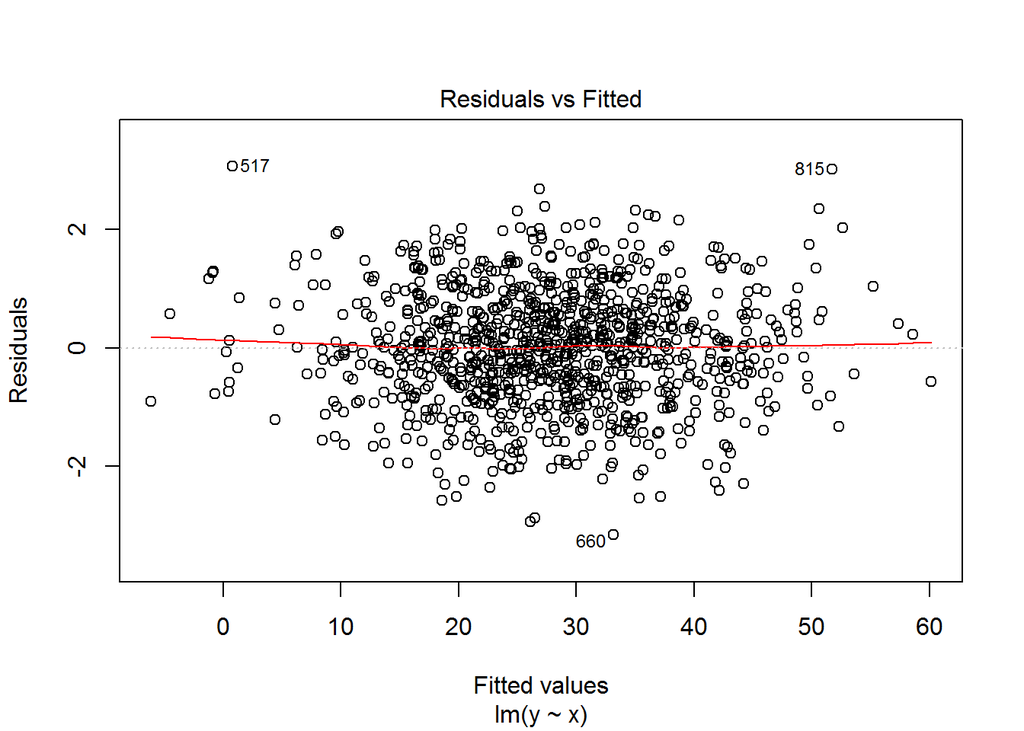

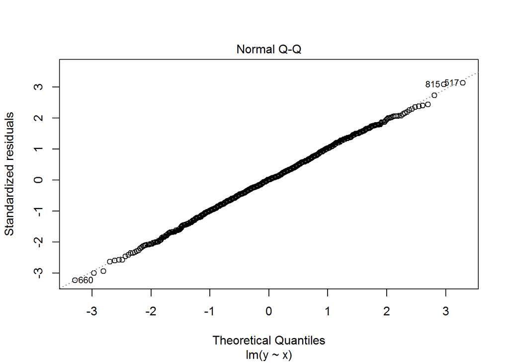

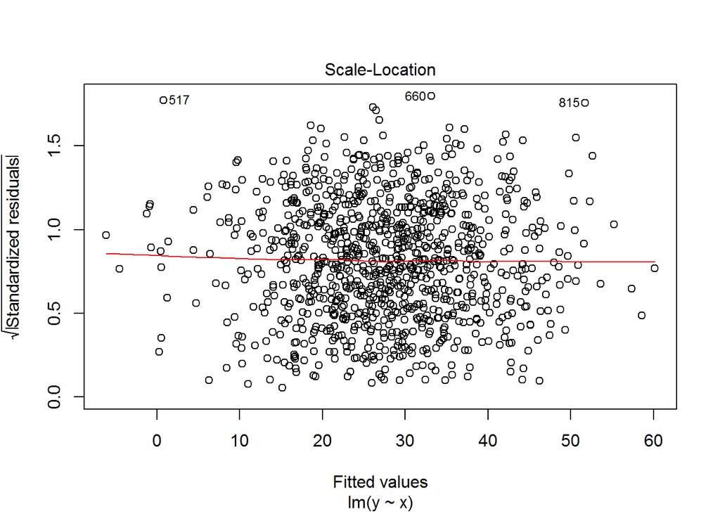

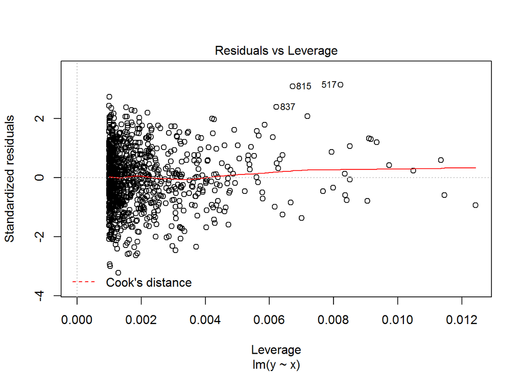

```r
plot(fit)   ## model diagnostic plots
```

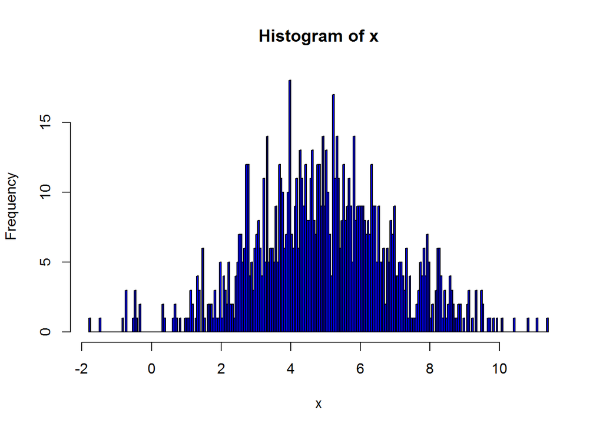

```r
hist(x, breaks=200, col="blue")   ##  histgram of x
```

```r
mean(x)   ## mean of x
```

```
## [1] 4.946806
```

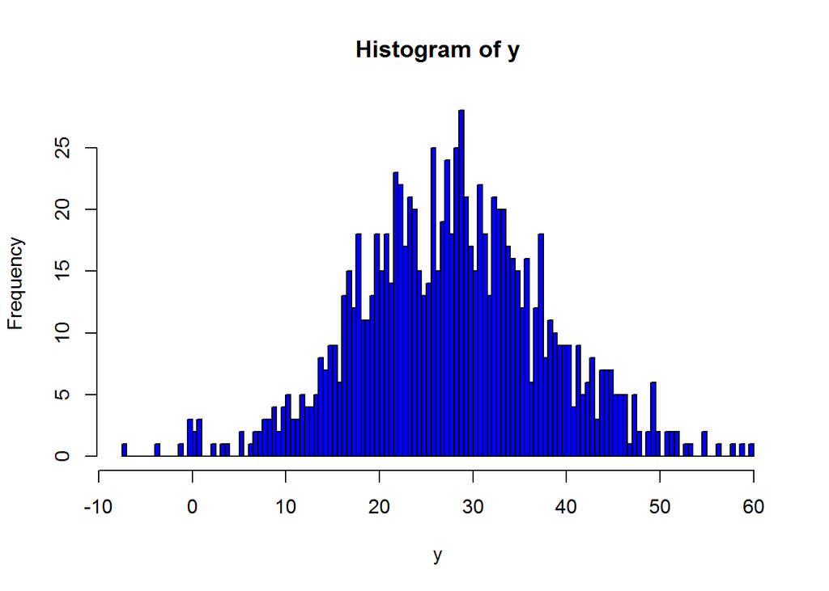

```r
hist(y, breaks=200, col="blue")   ##  histgram of y
```

```r
mean(y)   ## mean of y
```

```
## [1] 27.74854
```

```r
3+5*mean(x)+0   ## relation between mean values
```

```
## [1] 27.73403
```

```r
cor.test(x,y)  ## Pearson correlation
```

```
##
##  Pearson's product-moment correlation
##
## data:  x and y
## t = 323.42, df = 998, p-value < 2.2e-16
## alternative hypothesis: true correlation is not equal to 0
## 95 percent confidence interval:
##  0.9946388 0.9958151
## sample estimates:
##       cor
## 0.9952633
```

```r
cor.test(x,y)$statistic^2  ## two-sample t-test statistics square
```

```
##        t
## 104598.9
```

```r
summary(fit)$fstatistic[1]  ## simple Gaussian regression F statistics
```

```
##    value
## 104598.9
```

**6. Run the following code to attach a dataset first. Then test the linear association between variable HEARTRTE and variable BMI while adjusting for variable age effect on HEARTRTE.**

```r
data("DIGdata", package="asympTest")
attach(DIGdata)
```

**Solution:**

```r
summary(HEARTRTE)
```

```
##    Min. 1st Qu.  Median    Mean 3rd Qu.    Max.    NA's
##   40.00   70.00   80.00   78.76   88.00  156.00       8
```

```r
summary(AGE)
```

```
##    Min. 1st Qu.  Median    Mean 3rd Qu.    Max.
##   21.00   57.00   65.00   63.48   71.00   94.00
```

```r
summary(BMI)
```

```
##    Min. 1st Qu.  Median    Mean 3rd Qu.    Max.    NA's
##   14.44   23.68   26.50   27.11   29.80   62.66       1
```

```r
fit <- lm(HEARTRTE ~ AGE+BMI)  ## Run multivariate regression
summary(fit)
```

```
##
## Call:
## lm(formula = HEARTRTE ~ AGE + BMI)
##
## Residuals:
##     Min      1Q  Median      3Q     Max
## -39.208  -8.638   0.529   8.877  77.729
##
## Coefficients:
##             Estimate Std. Error t value Pr(>|t|)
## (Intercept) 75.44503    1.21070  62.315   <2e-16 ***
## AGE          0.02330    0.01406   1.657   0.0975 .
## BMI          0.06767    0.02957   2.289   0.0221 *
## ---
## Signif. codes:  0 '***' 0.001 '**' 0.01 '*' 0.05 '.' 0.1 ' ' 1
##
## Residual standard error: 12.65 on 6788 degrees of freedom
##   (9 observations deleted due to missingness)
## Multiple R-squared:  0.001172,   Adjusted R-squared:  0.000878
## F-statistic: 3.984 on 2 and 6788 DF,  p-value: 0.01866
```

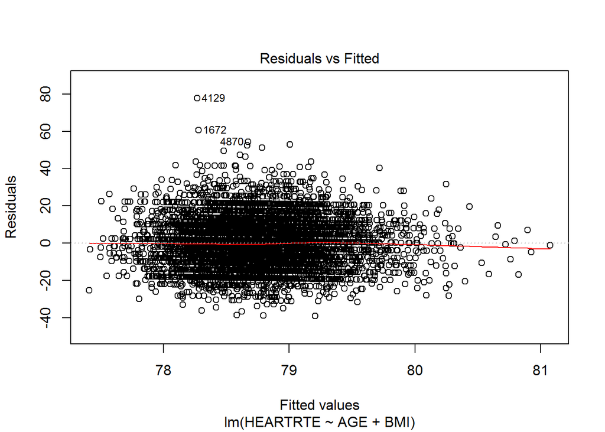

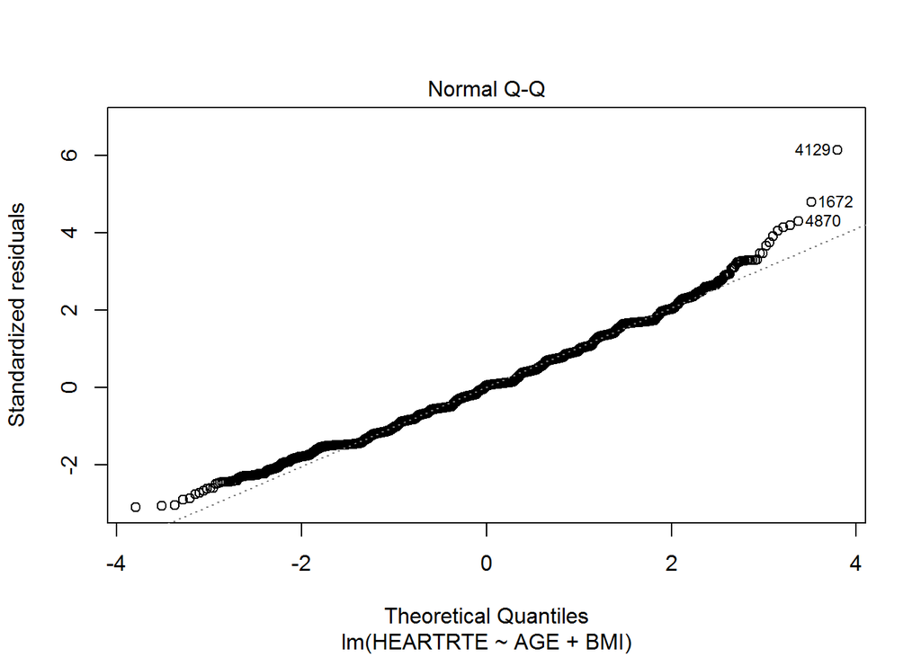

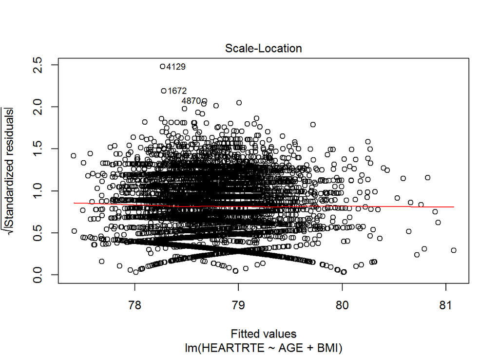

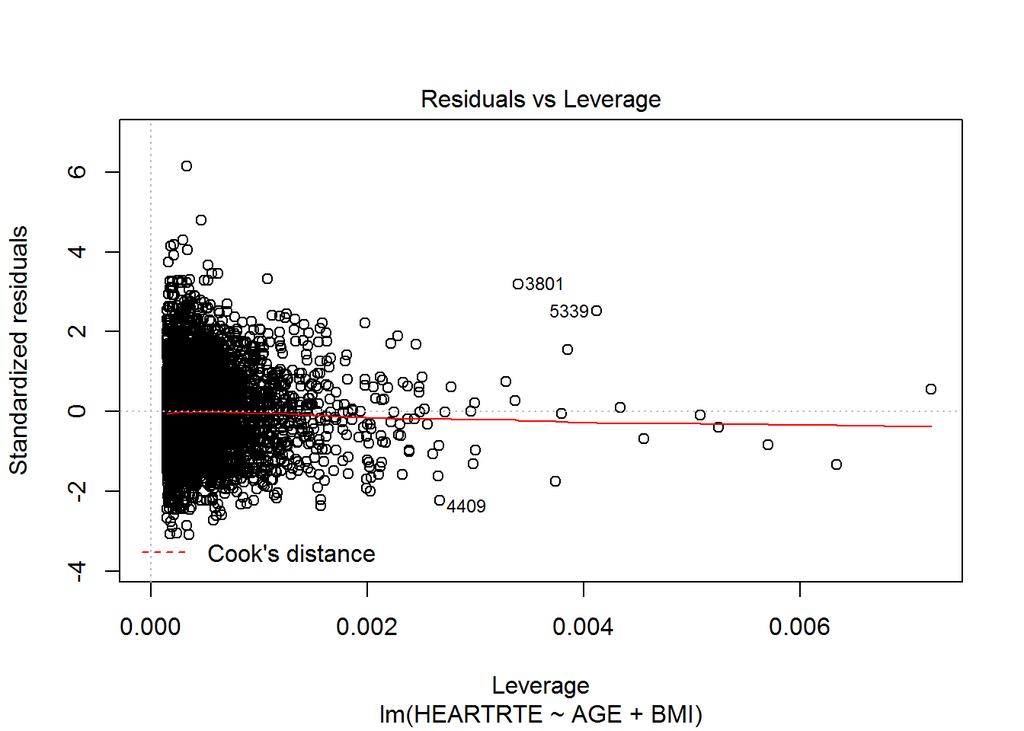

```r
## model diagnostics
plot(fit)
```

```r
car::ncvTest(fit)
```

```
## Non-constant Variance Score Test
## Variance formula: ~ fitted.values
## Chisquare = 2.526427    Df = 1     p = 0.1119534
```

```r
car::vif(fit)
```

```
##      AGE      BMI
## 1.000006 1.000006
```

```r
kappa(fit)^0.5
```

```
## [1] 19.85156
```

```r
cor.test(AGE, BMI)
```

```
##
##  Pearson's product-moment correlation
##
## data:  AGE and BMI
## t = -0.20944, df = 6797, p-value = 0.8341
## alternative hypothesis: true correlation is not equal to 0
## 95 percent confidence interval:
##  -0.02630931  0.02123153
## sample estimates:
##          cor
## -0.002540326
```

**7. Run the following simulation code first and then**

- **regress y on x**
- **generate the model diagnostic plots**
- **generate a histgram of y**
- **generate a frequency table of x**
- **generate a boxplot of y by different values of x**
- **run two-sample t-test on y by different values of x**

```r
set.seed(1234)
x <- rbinom(1000, 1, 0.5)
y <- 3+15*x+rnorm(1000)
```

**Solution:**

```r
fit <- lm(y~x)
summary(fit)
```

```
##
## Call:
## lm(formula = y ~ x)
##
## Residuals:
##      Min       1Q   Median       3Q      Max
## -2.91177 -0.62350  0.01231  0.63503  2.71819
##
## Coefficients:
##             Estimate Std. Error t value Pr(>|t|)
## (Intercept)  3.00510    0.04323   69.52   <2e-16 ***
## x           14.96762    0.06006  249.21   <2e-16 ***
## ---
## Signif. codes:  0 '***' 0.001 '**' 0.01 '*' 0.05 '.' 0.1 ' ' 1
##
## Residual standard error: 0.949 on 998 degrees of freedom
## Multiple R-squared:  0.9842, Adjusted R-squared:  0.9842
## F-statistic: 6.211e+04 on 1 and 998 DF,  p-value: < 2.2e-16
```

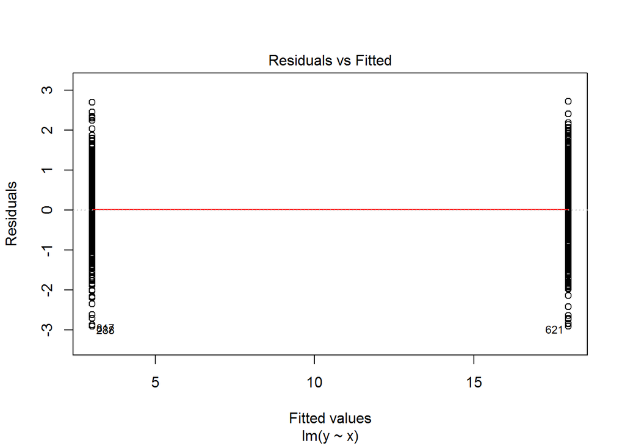

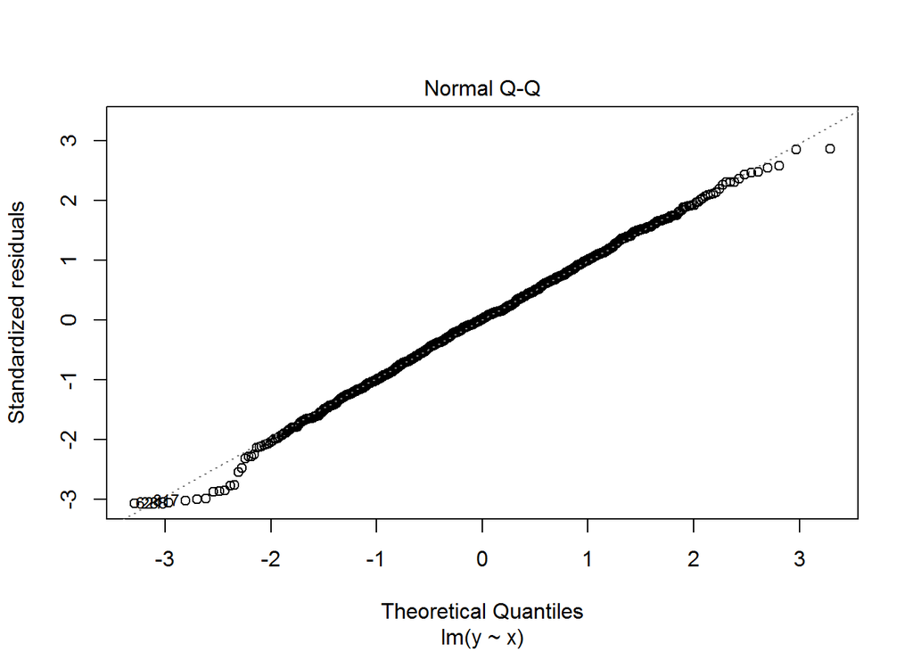

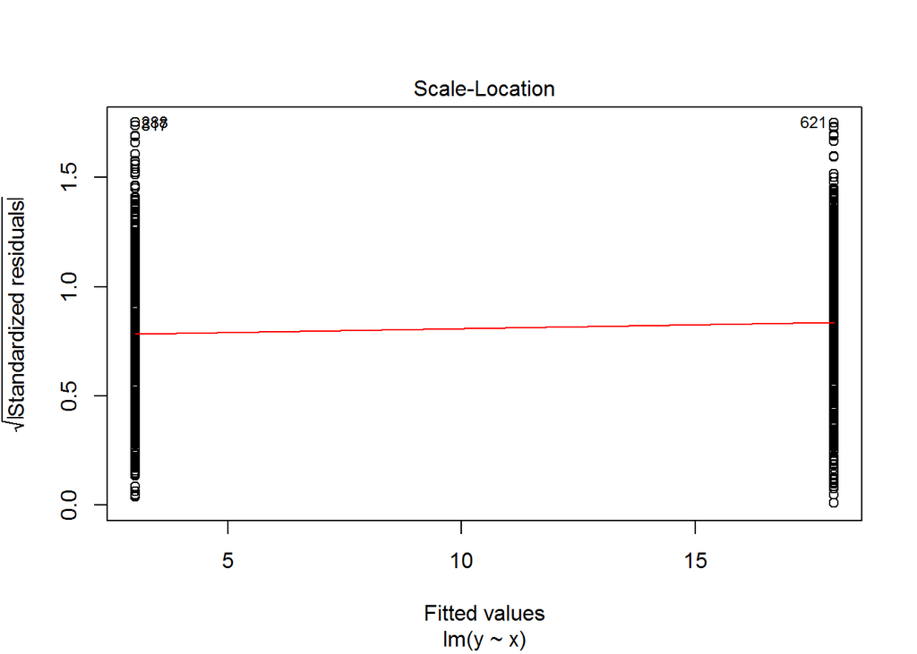

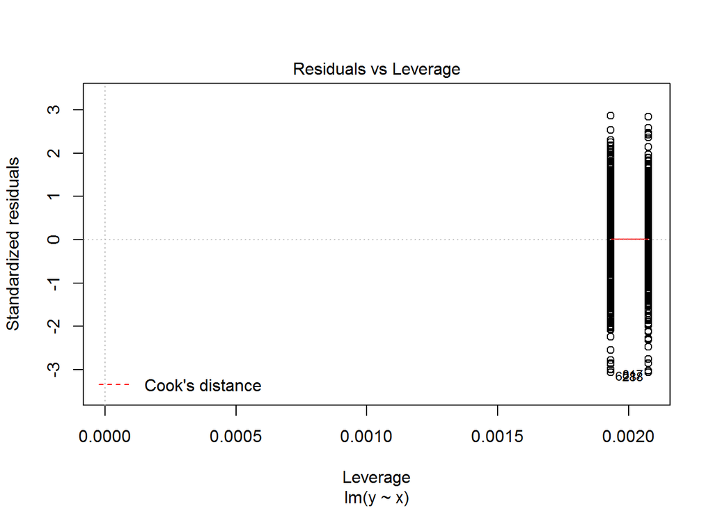

```r
plot(fit)
```

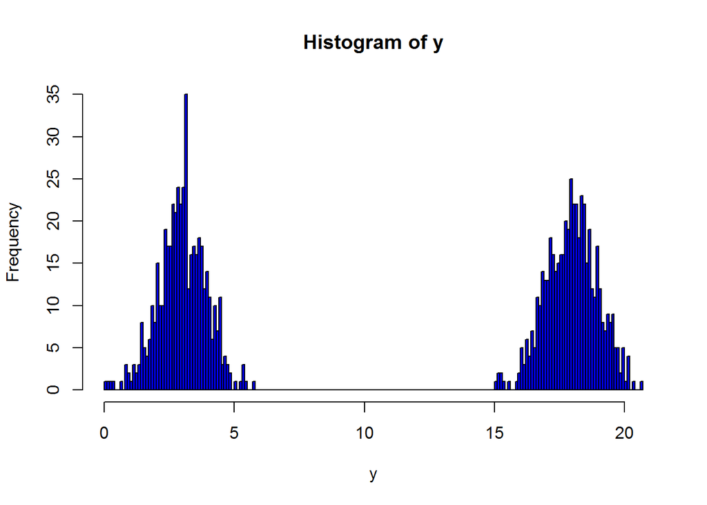

```r
hist(y, breaks=200, col="blue")
```

```r
table(x)
```

```
## x
##   0   1
## 482 518
```

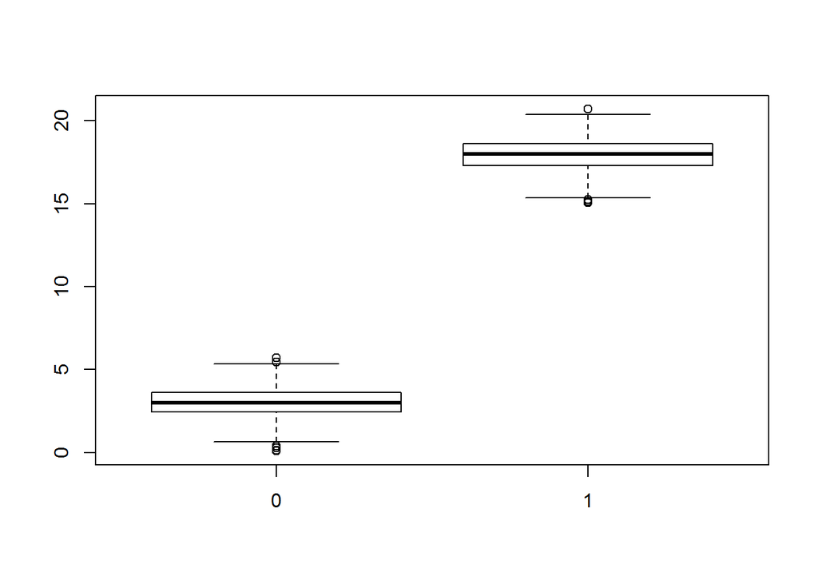

```r
boxplot(y~as.character(x))
```

```r
t.test(y~as.character(x))
```

```
##
##  Welch Two Sample t-test
##
## data:  y by as.character(x)
## t = -249.93, df = 997.94, p-value < 2.2e-16
## alternative hypothesis: true difference in means is not equal to 0
## 95 percent confidence interval:
##  -15.08514 -14.85009
## sample estimates:
## mean in group 0 mean in group 1
##        3.005098       17.972714
```